# BMF Pipeline Quality Report

Post-Transformation Validation Results

Published

September 15, 2026

# Executive Summary

**TipOverall Status: PASSED**

**Pipeline Timestamp:** 2026-09-14 21:03:19

| Metric | Value |
| --- | --- |
| Total Records | 1,788,300 |
| Output Columns | 110 |
| Overall Completeness | 62.0% |
| Row Preservation | Passed |
| Unique EINs | 1,786,293 |
| Duplicate EINs | 2,007 |

# Field Completeness by Category

This section shows the completeness of each output field, grouped by category. Each field shows its source column(s) from the raw BMF file.

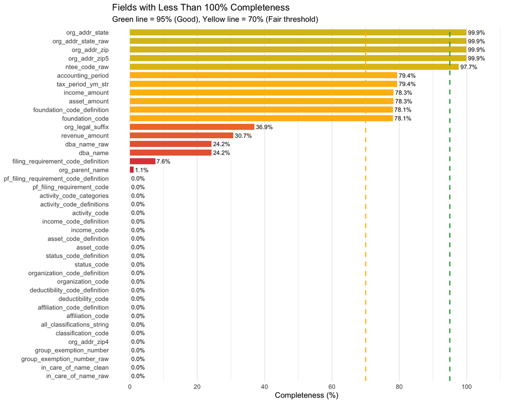

Fields with Incomplete Data

## Identity

**Average Completeness:** 100.0% | **Columns:** 2

| Field | Source | Completeness | Status | Null Count |
| --- | --- | --- | --- | --- |
| ein | EIN | 100.0% | Good | 0 |
| ein_raw | EIN | 100.0% | Good | 0 |

**Column Descriptions:**

- **ein**: Employer Identification Number formatted as XX-XXXXXXX
- **ein_raw**: Source EIN as ingested (non-digits removed, NOT left-zero-padded) — a lossy bare-integer surface (e.g. 000000004 -> 4). Use ein, ein_prefixed, or EIN2 for a safe join key.

## Organization Name

**Average Completeness:** 67.6% | **Columns:** 5

| Field | Source | Completeness | Status | Null Count |
| --- | --- | --- | --- | --- |
| org_name_raw | NAME | 100.0% | Good | 0 |
| org_name_join | NAME | 100.0% | Good | 0 |
| org_name_display | NAME | 100.0% | Good | 0 |
| org_legal_suffix | NAME | 36.9% | Low | 1,127,932 |
| org_parent_name | NAME | 1.1% | Low | 1,768,406 |

**Column Descriptions:**

- **org_name_raw**: Original organization name exactly as it appears in the source file
- **org_name_join**: Standardized name for matching and joining (uppercase, punctuation removed)
- **org_name_display**: Title-cased organization name suitable for display purposes
- **org_legal_suffix**: Legal entity suffix extracted from name (Inc, Corp, LLC, Foundation, etc.)
- **org_parent_name**: Parent organization name if this is a subordinate/chapter organization

## DBA Name

**Average Completeness:** 24.2% | **Columns:** 2

| Field | Source | Completeness | Status | Null Count |
| --- | --- | --- | --- | --- |
| dba_name | SORT_NAME | 24.2% | Low | 1,354,909 |
| dba_name_raw | SORT_NAME | 24.2% | Low | 1,354,909 |

**Column Descriptions:**

- **dba_name**: Cleaned ‘Doing Business As’ name
- **dba_name_raw**: Original secondary/DBA name from source file

## In Care Of

**Average Completeness:** 33.3% | **Columns:** 3

| Field | Source | Completeness | Status | Null Count |
| --- | --- | --- | --- | --- |
| in_care_of_name_raw | ICO | 0.0% | Low | 1,788,300 |
| in_care_of_name_clean | ICO | 0.0% | Low | 1,788,300 |
| in_care_of_name_provided | ICO | 100.0% | Good | 0 |

**Column Descriptions:**

- **in_care_of_name_raw**: Original ‘In Care Of’ field from source file
- **in_care_of_name_clean**: Cleaned ICO name with standardized formatting
- **in_care_of_name_provided**: Boolean indicating whether an ICO name was provided

## Group Exemption

**Average Completeness:** 33.3% | **Columns:** 3

| Field | Source | Completeness | Status | Null Count |
| --- | --- | --- | --- | --- |
| group_exemption_number_raw | GROUP | 0.0% | Low | 1,788,300 |
| group_exemption_number | GROUP | 0.0% | Low | 1,788,300 |
| group_exemption_is_member | GROUP | 100.0% | Good | 0 |

**Column Descriptions:**

- **group_exemption_number_raw**: Original group exemption number from source file
- **group_exemption_number**: Cleaned group exemption number (GEN)
- **group_exemption_is_member**: Boolean indicating if organization is a member of a group exemption

## Address (Raw)

**Average Completeness:** 100.0% | **Columns:** 4

| Field | Source | Completeness | Status | Null Count |
| --- | --- | --- | --- | --- |
| org_addr_street_raw | STREET | 100.0% | Good | 1 |
| org_addr_city_raw | CITY | 100.0% | Good | 0 |
| org_addr_state_raw | STATE | 99.9% | Good | 1,050 |
| org_addr_zip_raw | ZIP | 100.0% | Good | 0 |

**Column Descriptions:**

- **org_addr_street_raw**: Original street address from source file
- **org_addr_city_raw**: Original city name from source file
- **org_addr_state_raw**: Original state code from source file
- **org_addr_zip_raw**: Original ZIP code from source file

## Address (Cleaned)

**Average Completeness:** 85.7% | **Columns:** 7

| Field | Source | Completeness | Status | Null Count |
| --- | --- | --- | --- | --- |
| org_addr_street | STREET | 100.0% | Good | 1 |
| org_addr_city | CITY | 100.0% | Good | 0 |
| org_addr_state | STATE | 99.9% | Good | 1,050 |
| org_addr_zip5 | ZIP | 99.9% | Good | 1,250 |
| org_addr_zip4 | ZIP | 0.0% | Low | 1,788,300 |
| org_addr_zip | ZIP | 99.9% | Good | 1,250 |
| org_addr_full | STREET, CITY, STATE, ZIP | 100.0% | Good | 0 |

**Column Descriptions:**

- **org_addr_street**: Standardized street address with USPS abbreviations
- **org_addr_city**: Cleaned city name
- **org_addr_state**: Two-letter state abbreviation
- **org_addr_zip5**: 5-digit ZIP code
- **org_addr_zip4**: 4-digit ZIP code extension (if available)
- **org_addr_zip**: Full ZIP code (5 or 9 digits)
- **org_addr_full**: Complete formatted address string

## Address Quality Flags

**Average Completeness:** 100.0% | **Columns:** 6

| Field | Source | Completeness | Status | Null Count |
| --- | --- | --- | --- | --- |
| org_addr_is_missing | STREET, CITY, STATE, ZIP | 100.0% | Good | 0 |
| org_addr_is_po_box | STREET | 100.0% | Good | 0 |
| org_addr_is_rural_route | STREET | 100.0% | Good | 0 |
| org_addr_has_special_chars | STREET | 100.0% | Good | 0 |
| org_addr_missing_number | STREET | 100.0% | Good | 0 |
| org_addr_state_invalid | STATE | 100.0% | Good | 0 |

**Column Descriptions:**

- **org_addr_is_missing**: TRUE if street address is missing or empty
- **org_addr_is_po_box**: TRUE if address is a P.O. Box
- **org_addr_is_rural_route**: TRUE if address is a rural route
- **org_addr_has_special_chars**: TRUE if address contains unusual special characters
- **org_addr_missing_number**: TRUE if street address lacks a street number
- **org_addr_state_invalid**: TRUE if state code is not a valid US state/territory

## Classification

**Average Completeness:** 50.0% | **Columns:** 4

| Field | Source | Completeness | Status | Null Count |
| --- | --- | --- | --- | --- |
| subsection_code | SUBSECTION | 100.0% | Good | 0 |
| classification_code | CLASSIFICATION | 0.0% | Low | 1,788,300 |
| exempt_organization_type | SUBSECTION | 100.0% | Good | 30 |
| all_classifications_string | CLASSIFICATION | 0.0% | Low | 1,788,300 |

**Column Descriptions:**

- **subsection_code**: IRS subsection code (e.g., 03 for 501(c)(3), 04 for 501(c)(4))
- **classification_code**: IRS classification code indicating organization type within subsection
- **exempt_organization_type**: Human-readable exempt organization type based on subsection
- **all_classifications_string**: Semicolon-separated list of all classification descriptions

## Organization Codes

**Average Completeness:** 23.3% | **Columns:** 11

| Field | Source | Completeness | Status | Null Count |
| --- | --- | --- | --- | --- |
| affiliation_code | AFFILIATION | 0.0% | Low | 1,788,300 |
| affiliation_code_definition | AFFILIATION | 0.0% | Low | 1,788,300 |
| deductibility_code | DEDUCTIBILITY | 0.0% | Low | 1,788,300 |
| deductibility_code_definition | DEDUCTIBILITY | 0.0% | Low | 1,788,300 |
| foundation_code | FOUNDATION | 78.1% | Fair | 391,943 |
| foundation_code_definition | FOUNDATION | 78.1% | Fair | 391,944 |
| organization_code | ORGANIZATION | 0.0% | Low | 1,788,300 |
| organization_code_definition | ORGANIZATION | 0.0% | Low | 1,788,300 |
| status_code | STATUS | 0.0% | Low | 1,788,300 |
| status_code_definition | STATUS | 0.0% | Low | 1,788,300 |
| naics_code | NTEE_CD | 100.0% | Good | 0 |

**Column Descriptions:**

- **affiliation_code**: Code indicating relationship to parent organization (1-9)
- **affiliation_code_definition**: Description of affiliation relationship
- **deductibility_code**: Code indicating deductibility status of contributions (1-4)
- **deductibility_code_definition**: Description of contribution deductibility
- **foundation_code**: Foundation status code (00-99) per IRS determination
- **foundation_code_definition**: Description of foundation/public charity status
- **organization_code**: Code for type of organization (corporation, trust, etc.)
- **organization_code_definition**: Description of organization type
- **status_code**: IRS determination status code (01-99)
- **status_code_definition**: Description of exempt status
- **naics_code**: North American Industry Classification System code derived from NTEE

## Dates

**Average Completeness:** 94.1% | **Columns:** 7

| Field | Source | Completeness | Status | Null Count |
| --- | --- | --- | --- | --- |
| ruling_date_ym_str | RULING | 100.0% | Good | 0 |
| ruling_date | RULING | 100.0% | Good | 0 |
| ruling_date_is_missing | RULING | 100.0% | Good | 0 |
| tax_period_ym_str | TAX_PERIOD | 79.4% | Fair | 368,989 |
| tax_period_ymd | TAX_PERIOD | 100.0% | Good | 0 |
| tax_period_is_missing | TAX_PERIOD | 100.0% | Good | 0 |
| accounting_period | ACCT_PD | 79.4% | Fair | 368,989 |

**Column Descriptions:**

- **ruling_date_ym_str**: Ruling date as YYYYMM string
- **ruling_date**: Date of IRS ruling granting exempt status
- **ruling_date_is_missing**: TRUE if ruling date is missing or invalid
- **tax_period_ym_str**: Tax period end date as YYYYMM string
- **tax_period_ymd**: Tax period end date in YYYY-MM-DD format
- **tax_period_is_missing**: TRUE if tax period is missing
- **accounting_period**: Month when organization’s accounting period ends (01-12)

## Financial Codes

**Average Completeness:** 0.0% | **Columns:** 4

| Field | Source | Completeness | Status | Null Count |
| --- | --- | --- | --- | --- |
| asset_code | ASSET_CD | 0.0% | Low | 1,788,300 |
| asset_code_definition | ASSET_CD | 0.0% | Low | 1,788,300 |
| income_code | INCOME_CD | 0.0% | Low | 1,788,300 |
| income_code_definition | INCOME_CD | 0.0% | Low | 1,788,300 |

**Column Descriptions:**

- **asset_code**: Asset amount range code (0-9)
- **asset_code_definition**: Description of asset range (e.g., ‘$100,000 to $499,999’)
- **income_code**: Income amount range code (0-9)
- **income_code_definition**: Description of income range

## Financial Amounts

**Average Completeness:** 62.4% | **Columns:** 3

| Field | Source | Completeness | Status | Null Count |
| --- | --- | --- | --- | --- |
| asset_amount | ASSET_AMT | 78.3% | Fair | 387,948 |
| income_amount | INCOME_AMT | 78.3% | Fair | 387,948 |
| revenue_amount | REVENUE_AMT | 30.7% | Low | 1,239,370 |

**Column Descriptions:**

- **asset_amount**: Total assets in dollars (most recent return)
- **income_amount**: Total income in dollars (can be negative)
- **revenue_amount**: Total revenue in dollars (can be negative)

## Activity

**Average Completeness:** 0.0% | **Columns:** 3

| Field | Source | Completeness | Status | Null Count |
| --- | --- | --- | --- | --- |
| activity_code | ACTIVITY | 0.0% | Low | 1,788,300 |
| activity_code_definitions | ACTIVITY | 0.0% | Low | 1,788,300 |
| activity_code_categories | ACTIVITY | 0.0% | Low | 1,788,300 |

**Column Descriptions:**

- **activity_code**: Three 3-digit activity codes concatenated (9 characters total)
- **activity_code_definitions**: Semicolon-separated descriptions of activity codes
- **activity_code_categories**: Semicolon-separated activity categories

## Filing Requirements

**Average Completeness:** 26.9% | **Columns:** 4

| Field | Source | Completeness | Status | Null Count |
| --- | --- | --- | --- | --- |
| filing_requirement_code | FILING_REQ_CD | 100.0% | Good | 0 |
| filing_requirement_code_definition | FILING_REQ_CD | 7.6% | Low | 1,653,023 |
| pf_filing_requirement_code | PF_FILING_REQ_CD | 0.0% | Low | 1,788,300 |
| pf_filing_requirement_code_definition | PF_FILING_REQ_CD | 0.0% | Low | 1,788,300 |

**Column Descriptions:**

- **filing_requirement_code**: Code indicating required annual return form (0-6)
- **filing_requirement_code_definition**: Description of filing requirement (990, 990-EZ, 990-N, etc.)
- **pf_filing_requirement_code**: Private foundation filing requirement code
- **pf_filing_requirement_code_definition**: Description of private foundation filing requirement

## NTEE Codes

**Average Completeness:** 99.6% | **Columns:** 6

| Field | Source | Completeness | Status | Null Count |
| --- | --- | --- | --- | --- |
| ntee_code_raw | NTEE_CD | 97.7% | Good | 41,768 |
| ntee_code_clean | NTEE_CD | 100.0% | Good | 0 |
| ntee_code_definition | NTEE_CD | 100.0% | Good | 0 |
| ntee_code_major_group | NTEE_CD | 100.0% | Good | 0 |
| ntee_common_code | NTEE_CD | 100.0% | Good | 0 |
| ntee_common_code_definition | NTEE_CD | 100.0% | Good | 0 |

**Column Descriptions:**

- **ntee_code_raw**: Original NTEE code from source file (1-4 characters)
- **ntee_code_clean**: Standardized 3-character NTEE code
- **ntee_code_definition**: Full description of NTEE classification
- **ntee_code_major_group**: NTEE major group letter (A-Z) indicating broad category
- **ntee_common_code**: Common code suffix for 4-character NTEE codes (e.g., 01-99)
- **ntee_common_code_definition**: Description of common code suffix

## NTEE V2 Codes

**Average Completeness:** 100.0% | **Columns:** 5

| Field | Source | Completeness | Status | Null Count |
| --- | --- | --- | --- | --- |
| nteev2 | NTEE_CD | 100.0% | Good | 0 |
| nteev2_code | NTEE_CD | 100.0% | Good | 0 |
| nteev2_subsector | NTEE_CD | 100.0% | Good | 0 |
| nteev2_subsector_definition | NTEE_CD | 100.0% | Good | 0 |
| nteev2_org_type | NTEE_CD | 100.0% | Good | 0 |

**Column Descriptions:**

- **nteev2**: Full NTEEv2 code in SUBSECTOR-CODE-TYPE format
- **nteev2_code**: NTEEv2 code portion (3 characters)
- **nteev2_subsector**: NTEEv2 subsector code (e.g., UNI, HOS, ART, ENV)
- **nteev2_subsector_definition**: Human-readable name of the NTEEv2 subsector (e.g., ‘Human Services’, ‘Public, Societal Benefit’)
- **nteev2_org_type**: NTEEv2 organization type (RG=Regular, AA=Alliance, etc.)

# Organization Distribution

## Exempt Organization Type

Distribution of organizations by exempt organization type (based on IRS subsection code).

[figure not shown]

Organizations by Exempt Type

| Exempt Organization Type | Count | Percentage |
| --- | --- | --- |
| 501(c)(3) | 1,438,655 | 80.45% |
| 501(c)(4) | 76,559 | 4.28% |
| 501(c)(6) | 61,617 | 3.45% |
| 501(c)(7) | 48,350 | 2.70% |
| 501(c)(5) | 45,192 | 2.53% |
| 501(c)(8) | 39,646 | 2.22% |
| 501(c)(19) | 27,393 | 1.53% |
| 501(c)(10) | 15,505 | 0.87% |
| 501(c)(13) | 9,546 | 0.53% |
| 4947(a)(1) | 6,515 | 0.36% |
| 501(c)(9) | 5,713 | 0.32% |
| 501(c)(12) | 5,403 | 0.30% |
| 501(c)(2) | 4,339 | 0.24% |
| 501(c)(14) | 1,566 | 0.09% |
| 501(c)(1) | 680 | 0.04% |
| 501(c)(15) | 629 | 0.04% |
| 501(c)(25) | 580 | 0.03% |
| 501(d) | 217 | 0.01% |
| 501(c)(17) | 85 | 0.00% |
| NA | 30 | 0.00% |
| 501(c)(29) | 17 | 0.00% |
| 501(c)(27) | 14 | 0.00% |
| 82 | 12 | 0.00% |
| 501(c)(16) | 11 | 0.00% |
| 501(c)(11) | 6 | 0.00% |
| 501(c)(26) | 6 | 0.00% |
| 501(e) | 5 | 0.00% |
| 501(c)(18) | 3 | 0.00% |
| 501(c)(23) | 2 | 0.00% |
| 529 | 1 | 0.00% |
| 501(n) | 1 | 0.00% |
| 501(c)(20) | 1 | 0.00% |
| 501(c)(21) | 1 | 0.00% |

## NTEE Major Group Distribution

Distribution of organizations by NTEE major group code.

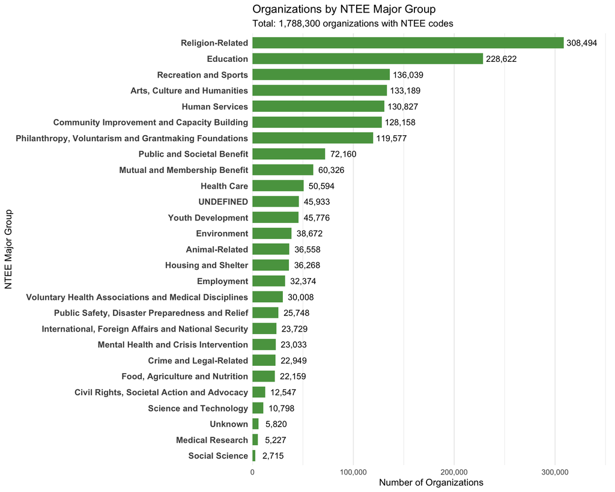

Organizations by NTEE Major Group

| NTEE Major Group | Count | Percentage |
| --- | --- | --- |
| Religion-Related | 308,494 | 17.25% |
| Education | 228,622 | 12.78% |
| Recreation and Sports | 136,039 | 7.61% |
| Arts, Culture and Humanities | 133,189 | 7.45% |
| Human Services | 130,827 | 7.32% |
| Community Improvement and Capacity Building | 128,158 | 7.17% |
| Philanthropy, Voluntarism and Grantmaking Foundations | 119,577 | 6.69% |
| Public and Societal Benefit | 72,160 | 4.04% |
| Mutual and Membership Benefit | 60,326 | 3.37% |
| Health Care | 50,594 | 2.83% |
| UNDEFINED | 45,933 | 2.57% |
| Youth Development | 45,776 | 2.56% |
| Environment | 38,672 | 2.16% |
| Animal-Related | 36,558 | 2.04% |
| Housing and Shelter | 36,268 | 2.03% |
| Employment | 32,374 | 1.81% |
| Voluntary Health Associations and Medical Disciplines | 30,008 | 1.68% |
| Public Safety, Disaster Preparedness and Relief | 25,748 | 1.44% |
| International, Foreign Affairs and National Security | 23,729 | 1.33% |
| Mental Health and Crisis Intervention | 23,033 | 1.29% |
| Crime and Legal-Related | 22,949 | 1.28% |
| Food, Agriculture and Nutrition | 22,159 | 1.24% |
| Civil Rights, Societal Action and Advocacy | 12,547 | 0.70% |
| Science and Technology | 10,798 | 0.60% |
| Unknown | 5,820 | 0.33% |
| Medical Research | 5,227 | 0.29% |
| Social Science | 2,715 | 0.15% |